# Reproducible Research - Peer Assessement 1

## Imputing missing values.

```r
MVcount <- sum(is.na(data$steps))
mv_pos <- which(is.na(data$steps))
mean_vec <- rep(mean(data$steps,na.rm=TRUE),times=length(mv_pos))
data[mv_pos, "steps"] <- mean_vec
total.steps <- aggregate(data$steps,by=list(data$date),FUN=sum)
names(total.steps) <- c("date","steps")
```

Make a histogram of the total number of steps taken each day.

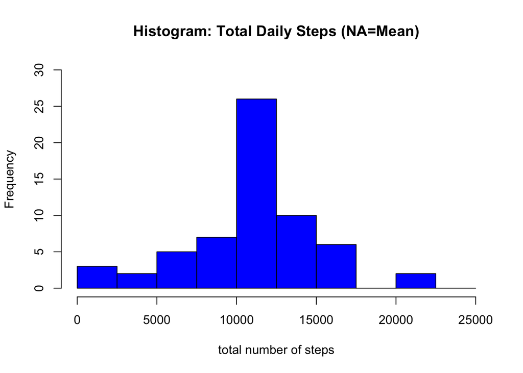

```r
hist(total.steps$steps,
     breaks=seq(from=0, to=25000, by=2500),
     col="blue",
     xlab="total number of steps",
     ylim=c(0, 30),
     main="Histogram: Total Daily Steps (NA=Mean)")
```

Calculate the mean and median of total daily steps.

```r
mean(total.steps$steps)
median(total.steps$steps)
export(data,"hw1new.csv")
```

```
## [1] 10766.19
## [1] 10766.19
```

The mean and median of total daily steps are both 10766.19 respectively. hw1new.csv reads in the MV-fixed data set.

## Are there differences in activity patterns between weekdays and weekends?

As noted, data is already prepped and processed to make this comparison (see first section.)

```r
data <- read.csv("hw1new.csv")
mean_data <- aggregate(data$steps,by=list(data$daytype,data$weekday,
             data$interval), mean)
names(mean_data) <- c("daytype", "weekday", "interval", "mean")
```

Create a panel plot comparing the average number of steps taken during the week and on the weekend.

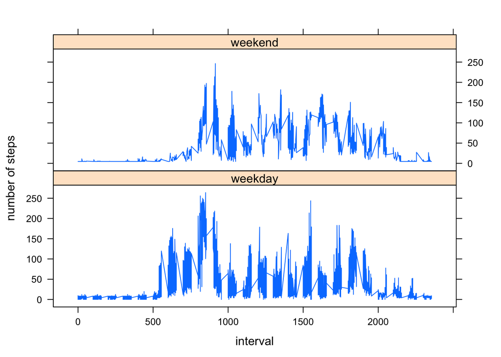

```r
library(lattice)
xyplot(mean~interval|daytype,mean_data,
       type="l",
       lwd=1,
       xlab="interval",
       ylab="number of steps",
       layout=c(1,2))
```